# PS9_JTung

```r
tree_data
```

```
## $segments
##       x         y xend      yend   n
## 2   2.5  964.7614  2.5 1022.8700 648
## 3   1.5  923.3760  1.5  964.7614 346
## 4   1.0  887.9782  1.0  923.3760 214
## 5   2.0  887.9782  2.0  923.3760 132
## 6   3.5  923.3760  3.5  964.7614 302
## 7   3.0  906.1555  3.0  923.3760 217
## 8   4.0  906.1555  4.0  923.3760  85
## 9   5.5  964.7614  5.5 1022.8700 168
## 10  5.0  950.7815  5.0  964.7614  45
## 11  6.0  950.7815  6.0  964.7614 123
## 21  4.0 1022.8700  2.5 1022.8700 648
## 31  2.5  964.7614  1.5  964.7614 346
## 41  1.5  923.3760  1.0  923.3760 214
```

[output cut: 30 more lines]

```r
# calculate the test error
pDT_fitted <- predict(vote_pDT, as_tibble(vote_split$test), type = "class")
ptree_err <- mean(as_tibble(vote_split$test)$vote96 != pDT_fitted)

ptree_err
```

```
## [1] 0.3037249
```

```r
# compare to the boosting method

# set random seed
set.seed(1234)

# run multiple models
vote_boost_testmodels <- list("boosting_depth1" = gbm(as.numeric(vote96) - 1 ~ .,
                                               data = vote_split$train,
                                               n.trees = 5000, interaction.depth = 1),
                              "boosting_depth2" = gbm(as.numeric(vote96) - 1 ~ .,
                                               data = vote_split$train,
                                               n.trees = 5000, interaction.depth = 2),
                              "boosting_depth4" = gbm(as.numeric(vote96) - 1 ~ .,
                                               data = vote_split$train,
                                               n.trees = 5000, interaction.depth = 4),
                              "boosting_depth10" = gbm(as.numeric(vote96) - 1 ~ .,
                                              data = vote_split$train,
                                              n.trees = 5000, interaction.depth = 10))
```

```
## Distribution not specified, assuming bernoulli ...
## Distribution not specified, assuming bernoulli ...
## Distribution not specified, assuming bernoulli ...
## Distribution not specified, assuming bernoulli ...
```

```r
# print the optimal tree number for each interaction depth
data_frame(depth = c(1, 2, 4, 10),
           model = vote_boost_testmodels[c("boosting_depth1", "boosting_depth2", "boosting_depth4", "boosting_depth10")],
           optimal = map_dbl(model, gbm.perf, plot.it = FALSE))
```

```
## Using OOB method...
## Using OOB method...
## Using OOB method...
## Using OOB method...
```

```
## # A tibble: 4 × 3
##   depth     model optimal
##   <dbl>    <list>   <dbl>
## 1     1 <S3: gbm>    3668
## 2     2 <S3: gbm>    2353
## 3     4 <S3: gbm>    1689
## 4    10 <S3: gbm>    1308
```

```r
# compare to the boosting method

# set random seed
set.seed(1234)

# run the models with the optimal number of trees
vote_boost_models <- list("boosting_depth1" = gbm(as.numeric(vote96) - 1 ~ .,
                                               data = vote_split$train,
                                               n.trees = 3647, interaction.depth = 1),
                          "boosting_depth2" = gbm(as.numeric(vote96) - 1 ~ .,
                                               data = vote_split$train,
                                               n.trees = 2442, interaction.depth = 2),
                          "boosting_depth4" = gbm(as.numeric(vote96) - 1 ~ .,
                                               data = vote_split$train,
                                               n.trees = 1739, interaction.depth = 4),
                          "boosting_depth10" = gbm(as.numeric(vote96) - 1 ~ .,
                                               data = vote_split$train,
                                               n.trees = 1305, interaction.depth = 10))
```

```
## Distribution not specified, assuming bernoulli ...
## Distribution not specified, assuming bernoulli ...
## Distribution not specified, assuming bernoulli ...
## Distribution not specified, assuming bernoulli ...
```

```r
# calculate test error for the different models using the test data
boost1_pred <- vote_test %>%
  mutate(pred = round(predict(vote_boost_models$boosting_depth1, newdata = as_tibble(vote_split$test), n.trees = 3647, type = "response")))
boost1_err <- mean(boost1_pred$pred != as.numeric(boost1_pred$vote96) - 1)

boost2_pred <- vote_test %>%
  mutate(pred = round(predict(vote_boost_models$boosting_depth2, newdata = as_tibble(vote_split$test), n.trees = 2442, type = "response")))
boost2_err <- mean(boost2_pred$pred != as.numeric(boost1_pred$vote96) - 1)

boost4_pred <- vote_test %>%
  mutate(pred = round(predict(vote_boost_models$boosting_depth4, newdata = as_tibble(vote_split$test), n.trees = 1739, type = "response")))
boost4_err <- mean(boost4_pred$pred != as.numeric(boost1_pred$vote96) - 1)

boost10_pred <- vote_test %>%
  mutate(pred = round(predict(vote_boost_models$boosting_depth10, newdata = as_tibble(vote_split$test), n.trees = 1305, type = "response")))
boost10_err <- mean(boost10_pred$pred != as.numeric(boost1_pred$vote96) - 1)


boost1_err
```

```
## [1] 0.2922636
```

```r
boost2_err
```

```
## [1] 0.2951289
```

```r
boost4_err
```

```
## [1] 0.2922636
```

```r
boost10_err
```

```
## [1] 0.2893983
```

```r
# compare to the random Forest method

# set the seed
set.seed(1234)

# perform bagging on the training set
vote_rf <- randomForest(vote96 ~ ., data = vote_split$train, ntree = 500)

# print results
print(vote_rf)
```

```
##
## Call:
##  randomForest(formula = vote96 ~ ., data = vote_split$train, ntree = 500)
##                Type of random forest: classification
##                      Number of trees: 500
## No. of variables tried at each split: 2
##
##         OOB estimate of  error rate: 29.78%
## Confusion matrix:
##     0   1 class.error
## 0 105 156   0.5977011
## 1  87 468   0.1567568
```

```r
err2 <- err.rate.tree(vote_rf,vote_split$test)
err2
```

```
## [1] 0.3008596
```

```r
set.seed(1234)
# try a linear kernal SVM application

# suggest a set of linear kernals to test
vote_lin_tune <- tune(svm, vote96 ~ ., data = as_tibble(vote_split$train),
                    kernel = "linear",
                    range = list(cost = c(.001, .01, .1, 1, 5, 10, 100)))
summary(vote_lin_tune)
```

```
##
## Parameter tuning of 'svm':
##
## - sampling method: 10-fold cross validation
##
## - best parameters:
##  cost
##     1
##
## - best performance: 0.2855616
##
## - Detailed performance results:
##    cost     error dispersion
## 1 1e-03 0.3199488 0.04400821
## 2 1e-02 0.3187293 0.04537108
## 3 1e-01 0.2929238 0.04148946
## 4 1e+00 0.2855616 0.02535048
## 5 5e+00 0.2892201 0.02894266
## 6 1e+01 0.2892201 0.02894266
## 7 1e+02 0.2892201 0.02894266
```

```r
# select best linear kernal model
vote_lin <- vote_lin_tune$best.model
summary(vote_lin)
```

```
##
## Call:
## best.tune(method = svm, train.x = vote96 ~ ., data = as_tibble(vote_split$train),
##     ranges = list(cost = c(0.001, 0.01, 0.1, 1, 5, 10, 100)),
##     kernel = "linear")
##
##
## Parameters:
##    SVM-Type:  C-classification
##  SVM-Kernel:  linear
##        cost:  1
##       gamma:  0.125
##
## Number of Support Vectors:  508
##
##  ( 256 252 )
##
##
## Number of Classes:  2
##
## Levels:
##  0 1
```

```r
set.seed(1234)
# try a polynomial kernal SVM application

# suggest a set of polynomial kernals to test
vote_poly_tune <- tune(svm, vote96  ~ ., data = as_tibble(vote_split$train),
                    kernel = "polynomial",
                    range = list(cost = c(.001, .01, .1, 1, 5, 10, 100)))
summary(vote_poly_tune)
```

```
##
## Parameter tuning of 'svm':
##
## - sampling method: 10-fold cross validation
##
## - best parameters:
##  cost
##     5
##
## - best performance: 0.3015206
##
## - Detailed performance results:
##    cost     error dispersion
## 1 1e-03 0.3199488 0.04400821
## 2 1e-02 0.3199488 0.04400821
## 3 1e-01 0.3175248 0.04919698
## 4 1e+00 0.3076784 0.03644975
## 5 5e+00 0.3015206 0.02944605
## 6 1e+01 0.3149955 0.03400944
## 7 1e+02 0.3248720 0.04069913
```

```r
# select best polynomial kernal model
vote_poly <- vote_poly_tune$best.model
summary(vote_poly)
```

```
##
## Call:
## best.tune(method = svm, train.x = vote96 ~ ., data = as_tibble(vote_split$train),
##     ranges = list(cost = c(0.001, 0.01, 0.1, 1, 5, 10, 100)),
##     kernel = "polynomial")
##
##
## Parameters:
##    SVM-Type:  C-classification
##  SVM-Kernel:  polynomial
##        cost:  5
##      degree:  3
##       gamma:  0.125
##      coef.0:  0
##
## Number of Support Vectors:  495
##
##  ( 258 237 )
##
##
## Number of Classes:  2
##
## Levels:
##  0 1
```

```r
set.seed(1234)
# try a radial kernal SVM application

# suggest a set of radial kernals to test
vote_rad_tune <- tune(svm, vote96  ~ ., data = as_tibble(vote_split$train),
                    kernel = "radial",
                    range = list(cost = c(.001, .01, .1, 1, 5, 10, 100)))
summary(vote_rad_tune)
```

```
##
## Parameter tuning of 'svm':
##
## - sampling method: 10-fold cross validation
##
## - best parameters:
##  cost
##     1
##
## - best performance: 0.2917344
##
## - Detailed performance results:
##    cost     error dispersion
## 1 1e-03 0.3199488 0.04400821
## 2 1e-02 0.3199488 0.04400821
## 3 1e-01 0.3064589 0.04453183
## 4 1e+00 0.2917344 0.03049168
## 5 5e+00 0.2954231 0.03999776
## 6 1e+01 0.2929840 0.03390399
## 7 1e+02 0.3199036 0.03130218
```

```r
# select best radial kernal model
vote_rad <- vote_rad_tune$best.model
summary(vote_rad)
```

```
##
## Call:
## best.tune(method = svm, train.x = vote96 ~ ., data = as_tibble(vote_split$train),
##     ranges = list(cost = c(0.001, 0.01, 0.1, 1, 5, 10, 100)),
##     kernel = "radial")
##
##
## Parameters:
##    SVM-Type:  C-classification
##  SVM-Kernel:  radial
##        cost:  1
##       gamma:  0.125
##
## Number of Support Vectors:  509
##
##  ( 265 244 )
##
##
## Number of Classes:  2
##
## Levels:
##  0 1
```

Part THREE: College

Perform PCA analysis on the college dataset and plot the first two principal components. Describe the results. What variables appear strongly correlated on the first principal component? What about the second principal component?

The results show that the first principal component (PC1) explains ~30%, while the second principal component (PC2) explains ~28% of the variance in the data. 18 total components are used to explain the total variance in the data. The variables strongly correlated with PC1 are those indicating high applicant achievement (top 10% or 25% of high school class), out of state tuition and expenditures per student, and finally those indicating highly-educated faculty, either holding PhD or terminal degrees. The variables strongly correlated with PC2 are the the number of full time undergraduates and number of new enrollees.

```r
# import necessary package
library(plyr)

# import the data
college <- read_csv("data/college.csv")

# manipulate data to turn categoricals into binary 1,0
college$Private <- mapvalues(college$Private, from = c("Yes", "No"), to = c(1, 0))
college$Private <- as.numeric(college$Private)

# perform PCA analysis
pr.out <- prcomp(college, scale = TRUE)
summary(pr.out)
```

```
## Importance of components:
##                           PC1    PC2     PC3     PC4     PC5     PC6
## Standard deviation     2.3367 2.2486 1.09068 1.02768 0.96716 0.92097
## Proportion of Variance 0.3033 0.2809 0.06609 0.05867 0.05197 0.04712
## Cumulative Proportion  0.3033 0.5842 0.65031 0.70899 0.76095 0.80807
##                            PC7     PC8     PC9    PC10    PC11    PC12
## Standard deviation     0.78517 0.76660 0.72941 0.64021 0.59818 0.55409
## Proportion of Variance 0.03425 0.03265 0.02956 0.02277 0.01988 0.01706
## Cumulative Proportion  0.84232 0.87497 0.90453 0.92730 0.94718 0.96424
##                           PC13    PC14    PC15    PC16   PC17    PC18
## Standard deviation     0.43076 0.40935 0.37910 0.29649 0.1898 0.15159
## Proportion of Variance 0.01031 0.00931 0.00798 0.00488 0.0020 0.00128
## Cumulative Proportion  0.97454 0.98385 0.99184 0.99672 0.9987 1.00000
```

```r
pr.out
```

```
## Standard deviations:
##  [1] 2.3366500 2.2485744 1.0906806 1.0276812 0.9671631 0.9209743 0.7851744
##  [8] 0.7665981 0.7294071 0.6402131 0.5981814 0.5540899 0.4307633 0.4093531
## [15] 0.3790965 0.2964863 0.1898153 0.1515867
##
## Rotation:
##                     PC1         PC2          PC3          PC4         PC5
## Private     -0.08900986  0.34587868 -0.151387220 -0.231134767  0.04428584
## Apps        -0.19963015 -0.34362075 -0.004820518 -0.305008587 -0.02296793
## Accept      -0.15379708 -0.37255665  0.025350623 -0.317485631  0.03143819
## Enroll      -0.11779674 -0.39969665  0.027576237 -0.204835867 -0.06566686
## Top10perc   -0.36034940  0.01623782 -0.004681414  0.107518827 -0.38822747
## Top25perc   -0.34475068 -0.01772991  0.058948294  0.146259632 -0.40980946
## F.Undergrad -0.09408770 -0.41073159  0.016806280 -0.143032399 -0.04658910
## P.Undergrad  0.01748305 -0.29306437 -0.149370877  0.097767116  0.32796741
## Outstate    -0.32766424  0.19151794 -0.066363490 -0.128798783  0.20325234
## Room.Board  -0.26653375  0.09397936 -0.182114368 -0.182426993  0.52625737
## Books       -0.05718904 -0.05733827 -0.662310022  0.089301319 -0.15855692
## Personal     0.07190001 -0.19275549 -0.469562857  0.290643137 -0.18799387
## PhD         -0.30325418 -0.11619109  0.208486014  0.464586282  0.20594933
## Terminal    -0.30386831 -0.10419229  0.146720479  0.460404255  0.26556187
## S.F.Ratio    0.21026024 -0.20439519  0.292254102  0.074900413 -0.05154016
## perc.alumni -0.23665864  0.19406065  0.159443221 -0.010001201 -0.21514060
## Expend      -0.33301113  0.07029054 -0.217318057 -0.007200544  0.05708796
## Grad.Rate   -0.27308629  0.11783035  0.172615147 -0.268200375 -0.14118696
##                      PC6           PC7          PC8         PC9
## Private     -0.031448151  0.1783453332 -0.032314015  0.08498490
## Apps        -0.008618207 -0.0610468173  0.099177178 -0.08408689
## Accept       0.013074177 -0.0154740645  0.054225155 -0.16527391
## Enroll      -0.043064515 -0.0082368272 -0.063261006 -0.11681296
## Top10perc   -0.059923032 -0.1444061158  0.097142718  0.35567639
## Top25perc    0.020614750 -0.0798885819  0.078062780  0.42244502
## F.Undergrad -0.045742837  0.0002822103 -0.083929629 -0.04976080
## P.Undergrad -0.196779247  0.1629649116 -0.569889535  0.54320137
## Outstate    -0.020295749  0.0949477894  0.004121687 -0.01143295
## Room.Board   0.183029223  0.1451416614  0.248673107  0.24424007
## Books        0.648309041 -0.1413707210 -0.225031850 -0.13326224
## Personal    -0.347055437  0.6091673284  0.301426790 -0.12160485
## PhD          0.071891961  0.0313471368  0.070546935 -0.16287300
## Terminal     0.138323131  0.0038470048  0.004631639 -0.23315421
```

[output cut: 27 more lines]

```
## Enroll       0.08152509  0.028480888  0.4039065035  0.6071736530
## Top10perc    0.10616979  0.697422249  0.1480179162 -0.1463077676
## Top25perc   -0.14867418 -0.616897126 -0.0501938895  0.0806060165
## F.Undergrad  0.05338564  0.009841915 -0.5697247043 -0.4089377085
## P.Undergrad -0.01955825  0.020679140  0.0506477287  0.0089628275
## Outstate     0.05720423  0.041948005 -0.0786220961  0.0480234655
## Room.Board   0.05596967  0.003513118  0.0288899486  0.0003682647
## Books        0.06768314 -0.009266266 -0.0017276648  0.0006031292
## Personal    -0.02660977 -0.003040725  0.0129110243 -0.0012110842
## PhD          0.68644924 -0.112694629 -0.0358422887  0.0151276042
## Terminal    -0.67455089  0.157864277  0.0202765132  0.0071429616
## S.F.Ratio   -0.04487049 -0.021719895  0.0148271328 -0.0012968711
## perc.alumni  0.02684047 -0.008154996 -0.0004830513 -0.0197045230
## Expend      -0.08087016 -0.228763729  0.0383171599 -0.0348628686
## Grad.Rate   -0.03722409 -0.003274235  0.0069960498 -0.0135066134
```

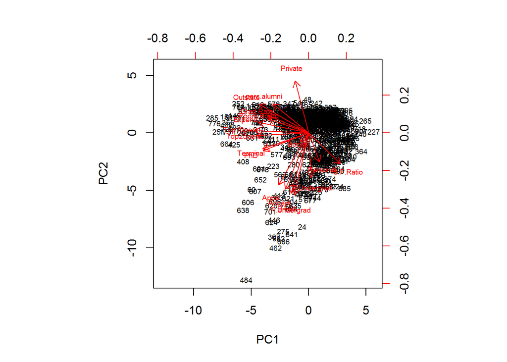

```r
# plot PC1 v PC2
biplot(pr.out, scale = 0, cex = .6)
```

```r
# view variable principal component loading vector
pr.out$rotation
```

```
##                     PC1         PC2          PC3          PC4         PC5
## Private     -0.08900986  0.34587868 -0.151387220 -0.231134767  0.04428584
## Apps        -0.19963015 -0.34362075 -0.004820518 -0.305008587 -0.02296793
## Accept      -0.15379708 -0.37255665  0.025350623 -0.317485631  0.03143819
## Enroll      -0.11779674 -0.39969665  0.027576237 -0.204835867 -0.06566686
## Top10perc   -0.36034940  0.01623782 -0.004681414  0.107518827 -0.38822747
## Top25perc   -0.34475068 -0.01772991  0.058948294  0.146259632 -0.40980946
## F.Undergrad -0.09408770 -0.41073159  0.016806280 -0.143032399 -0.04658910
## P.Undergrad  0.01748305 -0.29306437 -0.149370877  0.097767116  0.32796741
## Outstate    -0.32766424  0.19151794 -0.066363490 -0.128798783  0.20325234
## Room.Board  -0.26653375  0.09397936 -0.182114368 -0.182426993  0.52625737
## Books       -0.05718904 -0.05733827 -0.662310022  0.089301319 -0.15855692
## Personal     0.07190001 -0.19275549 -0.469562857  0.290643137 -0.18799387
## PhD         -0.30325418 -0.11619109  0.208486014  0.464586282  0.20594933
## Terminal    -0.30386831 -0.10419229  0.146720479  0.460404255  0.26556187
## S.F.Ratio    0.21026024 -0.20439519  0.292254102  0.074900413 -0.05154016
## perc.alumni -0.23665864  0.19406065  0.159443221 -0.010001201 -0.21514060
## Expend      -0.33301113  0.07029054 -0.217318057 -0.007200544  0.05708796
## Grad.Rate   -0.27308629  0.11783035  0.172615147 -0.268200375 -0.14118696
##                      PC6           PC7          PC8         PC9
## Private     -0.031448151  0.1783453332 -0.032314015  0.08498490
## Apps        -0.008618207 -0.0610468173  0.099177178 -0.08408689
## Accept       0.013074177 -0.0154740645  0.054225155 -0.16527391
## Enroll      -0.043064515 -0.0082368272 -0.063261006 -0.11681296
## Top10perc   -0.059923032 -0.1444061158  0.097142718  0.35567639
## Top25perc    0.020614750 -0.0798885819  0.078062780  0.42244502
## F.Undergrad -0.045742837  0.0002822103 -0.083929629 -0.04976080
## P.Undergrad -0.196779247  0.1629649116 -0.569889535  0.54320137
## Outstate    -0.020295749  0.0949477894  0.004121687 -0.01143295
## Room.Board   0.183029223  0.1451416614  0.248673107  0.24424007
## Books        0.648309041 -0.1413707210 -0.225031850 -0.13326224
## Personal    -0.347055437  0.6091673284  0.301426790 -0.12160485
## PhD          0.071891961  0.0313471368  0.070546935 -0.16287300
## Terminal     0.138323131  0.0038470048  0.004631639 -0.23315421
## S.F.Ratio    0.469366056  0.2757974605  0.094497566  0.28450760
## perc.alumni -0.051660779  0.2863608713 -0.640385918 -0.29052608
## Expend      -0.284474806 -0.2801681490  0.037568065 -0.05618403
## Grad.Rate    0.221847573  0.5016531283  0.077731964 -0.02261128
##                    PC10        PC11         PC12        PC13          PC14
## Private     -0.25959641  0.67975791 -0.245690232  0.40064866 -1.005658e-02
```

[output cut: 21 more lines]

```
## Enroll       0.08152509  0.028480888  0.4039065035  0.6071736530
## Top10perc    0.10616979  0.697422249  0.1480179162 -0.1463077676
## Top25perc   -0.14867418 -0.616897126 -0.0501938895  0.0806060165
## F.Undergrad  0.05338564  0.009841915 -0.5697247043 -0.4089377085
## P.Undergrad -0.01955825  0.020679140  0.0506477287  0.0089628275
## Outstate     0.05720423  0.041948005 -0.0786220961  0.0480234655
## Room.Board   0.05596967  0.003513118  0.0288899486  0.0003682647
## Books        0.06768314 -0.009266266 -0.0017276648  0.0006031292
## Personal    -0.02660977 -0.003040725  0.0129110243 -0.0012110842
## PhD          0.68644924 -0.112694629 -0.0358422887  0.0151276042
## Terminal    -0.67455089  0.157864277  0.0202765132  0.0071429616
## S.F.Ratio   -0.04487049 -0.021719895  0.0148271328 -0.0012968711
## perc.alumni  0.02684047 -0.008154996 -0.0004830513 -0.0197045230
## Expend      -0.08087016 -0.228763729  0.0383171599 -0.0348628686
## Grad.Rate   -0.03722409 -0.003274235  0.0069960498 -0.0135066134
```

```r
summary(pr.out)
```

```
## Importance of components:
##                           PC1    PC2     PC3     PC4     PC5     PC6
## Standard deviation     2.3367 2.2486 1.09068 1.02768 0.96716 0.92097
## Proportion of Variance 0.3033 0.2809 0.06609 0.05867 0.05197 0.04712
## Cumulative Proportion  0.3033 0.5842 0.65031 0.70899 0.76095 0.80807
##                            PC7     PC8     PC9    PC10    PC11    PC12
## Standard deviation     0.78517 0.76660 0.72941 0.64021 0.59818 0.55409
## Proportion of Variance 0.03425 0.03265 0.02956 0.02277 0.01988 0.01706
## Cumulative Proportion  0.84232 0.87497 0.90453 0.92730 0.94718 0.96424
##                           PC13    PC14    PC15    PC16   PC17    PC18
## Standard deviation     0.43076 0.40935 0.37910 0.29649 0.1898 0.15159
## Proportion of Variance 0.01031 0.00931 0.00798 0.00488 0.0020 0.00128
## Cumulative Proportion  0.97454 0.98385 0.99184 0.99672 0.9987 1.00000
```

```r
pr.out
```

```
## Standard deviations:
##  [1] 2.3366500 2.2485744 1.0906806 1.0276812 0.9671631 0.9209743 0.7851744
##  [8] 0.7665981 0.7294071 0.6402131 0.5981814 0.5540899 0.4307633 0.4093531
## [15] 0.3790965 0.2964863 0.1898153 0.1515867
##
## Rotation:
##                     PC1         PC2          PC3          PC4         PC5
## Private     -0.08900986  0.34587868 -0.151387220 -0.231134767  0.04428584
## Apps        -0.19963015 -0.34362075 -0.004820518 -0.305008587 -0.02296793
## Accept      -0.15379708 -0.37255665  0.025350623 -0.317485631  0.03143819
## Enroll      -0.11779674 -0.39969665  0.027576237 -0.204835867 -0.06566686
## Top10perc   -0.36034940  0.01623782 -0.004681414  0.107518827 -0.38822747
## Top25perc   -0.34475068 -0.01772991  0.058948294  0.146259632 -0.40980946
## F.Undergrad -0.09408770 -0.41073159  0.016806280 -0.143032399 -0.04658910
## P.Undergrad  0.01748305 -0.29306437 -0.149370877  0.097767116  0.32796741
## Outstate    -0.32766424  0.19151794 -0.066363490 -0.128798783  0.20325234
## Room.Board  -0.26653375  0.09397936 -0.182114368 -0.182426993  0.52625737
## Books       -0.05718904 -0.05733827 -0.662310022  0.089301319 -0.15855692
## Personal     0.07190001 -0.19275549 -0.469562857  0.290643137 -0.18799387
## PhD         -0.30325418 -0.11619109  0.208486014  0.464586282  0.20594933
## Terminal    -0.30386831 -0.10419229  0.146720479  0.460404255  0.26556187
## S.F.Ratio    0.21026024 -0.20439519  0.292254102  0.074900413 -0.05154016
## perc.alumni -0.23665864  0.19406065  0.159443221 -0.010001201 -0.21514060
## Expend      -0.33301113  0.07029054 -0.217318057 -0.007200544  0.05708796
## Grad.Rate   -0.27308629  0.11783035  0.172615147 -0.268200375 -0.14118696
##                      PC6           PC7          PC8         PC9
## Private     -0.031448151  0.1783453332 -0.032314015  0.08498490
## Apps        -0.008618207 -0.0610468173  0.099177178 -0.08408689
## Accept       0.013074177 -0.0154740645  0.054225155 -0.16527391
## Enroll      -0.043064515 -0.0082368272 -0.063261006 -0.11681296
## Top10perc   -0.059923032 -0.1444061158  0.097142718  0.35567639
## Top25perc    0.020614750 -0.0798885819  0.078062780  0.42244502
## F.Undergrad -0.045742837  0.0002822103 -0.083929629 -0.04976080
## P.Undergrad -0.196779247  0.1629649116 -0.569889535  0.54320137
## Outstate    -0.020295749  0.0949477894  0.004121687 -0.01143295
## Room.Board   0.183029223  0.1451416614  0.248673107  0.24424007
## Books        0.648309041 -0.1413707210 -0.225031850 -0.13326224
## Personal    -0.347055437  0.6091673284  0.301426790 -0.12160485
## PhD          0.071891961  0.0313471368  0.070546935 -0.16287300
## Terminal     0.138323131  0.0038470048  0.004631639 -0.23315421
```

[output cut: 27 more lines]

```
## Enroll       0.08152509  0.028480888  0.4039065035  0.6071736530
## Top10perc    0.10616979  0.697422249  0.1480179162 -0.1463077676
## Top25perc   -0.14867418 -0.616897126 -0.0501938895  0.0806060165
## F.Undergrad  0.05338564  0.009841915 -0.5697247043 -0.4089377085
## P.Undergrad -0.01955825  0.020679140  0.0506477287  0.0089628275
## Outstate     0.05720423  0.041948005 -0.0786220961  0.0480234655
## Room.Board   0.05596967  0.003513118  0.0288899486  0.0003682647
## Books        0.06768314 -0.009266266 -0.0017276648  0.0006031292
## Personal    -0.02660977 -0.003040725  0.0129110243 -0.0012110842
## PhD          0.68644924 -0.112694629 -0.0358422887  0.0151276042
## Terminal    -0.67455089  0.157864277  0.0202765132  0.0071429616
## S.F.Ratio   -0.04487049 -0.021719895  0.0148271328 -0.0012968711
## perc.alumni  0.02684047 -0.008154996 -0.0004830513 -0.0197045230
## Expend      -0.08087016 -0.228763729  0.0383171599 -0.0348628686
## Grad.Rate   -0.03722409 -0.003274235  0.0069960498 -0.0135066134
```

PART FOUR: Clustering States

IMPORT THE DATA!

```r
# import the data, remove NAs
crime <- read_csv("data/USArrests.csv") %>%
  na.omit
```

1. Perform PCA on the dataset and plot the observations on the first and second principal components.

PCA was performed on the data set. The Observations were plotted on the first and second principal components, below.

```r
# perform PCA
pr.out <- prcomp(x = select(crime, -State), scale = TRUE)
summary(pr.out)
```

```
## Importance of components:
##                           PC1    PC2     PC3     PC4
## Standard deviation     1.5749 0.9949 0.59713 0.41645
## Proportion of Variance 0.6201 0.2474 0.08914 0.04336
## Cumulative Proportion  0.6201 0.8675 0.95664 1.00000
```

```r
pr.out
```

```
## Standard deviations:
## [1] 1.5748783 0.9948694 0.5971291 0.4164494
##
## Rotation:
##                 PC1        PC2        PC3         PC4
## Murder   -0.5358995  0.4181809 -0.3412327  0.64922780
## Assault  -0.5831836  0.1879856 -0.2681484 -0.74340748
## UrbanPop -0.2781909 -0.8728062 -0.3780158  0.13387773
## Rape     -0.5434321 -0.1673186  0.8177779  0.08902432
```

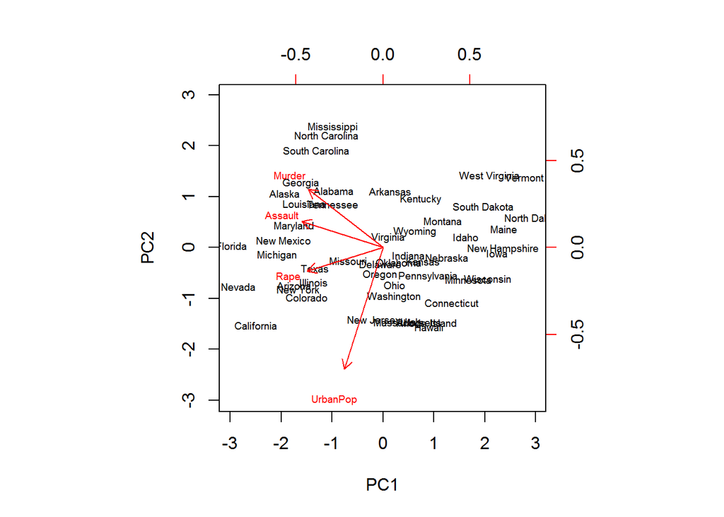

```r
# plot PC1 v PC2
biplot(pr.out, scale = 0, cex = .6, xlabs = crime$State)
```

```r
# view principal component loading vectors
pr.out$rotation
```

```
##                 PC1        PC2        PC3         PC4
## Murder   -0.5358995  0.4181809 -0.3412327  0.64922780
## Assault  -0.5831836  0.1879856 -0.2681484 -0.74340748
## UrbanPop -0.2781909 -0.8728062 -0.3780158  0.13387773
## Rape     -0.5434321 -0.1673186  0.8177779  0.08902432
```

2. Perform K-means clustering with K=2. Plot the observations on the first and second principal components and color-code each state based on their cluster membership. Describe your results.

The PCA above finds Murder, Assault and Rape to be strongly correlated with the first principal component and urban population to be most strongly correlated with the second primary component. We would interpret the plot below as likely reflecting the difference (by color) in “violent” versus “less violent” states (since PC1 reflects measures of violence, as indicated by the relative the magnitude of reported rotation output).

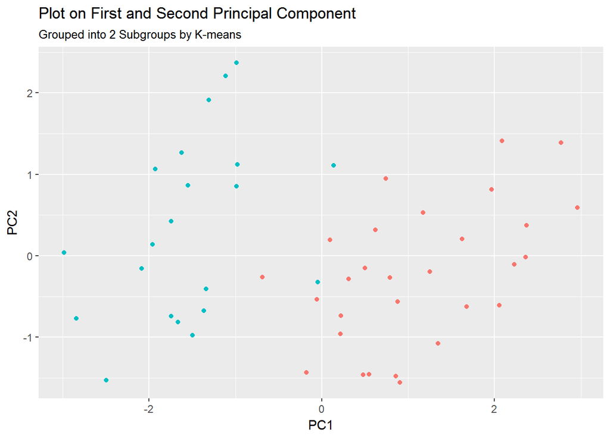

```r
# set the random seed
set.seed(1234)

# estimate k=2 clusters

# modify original dataframe to include kmeans cluster assignment and PC1 and PC2 scores
k2clust <- crime %>%
    mutate(k2 = as.factor(kmeans(crime[,2:5], 2, nstart = 1)$cluster),
           PC1 = as.data.frame(pr.out$x)$PC1,
           PC2 = as.data.frame(pr.out$x)$PC2)

# plot each data point on the PC1 and PC2 component with each state color-coded by cluster membership
k2clust %>%
  ggplot(aes(PC1, PC2, color = k2)) +
  geom_point() +
  theme(legend.position = "none") +
  labs(title = "Plot on First and Second Principal Component",
       subtitle = "Grouped into 2 Subgroups by K-means")
```

```r
pr.out
```

```
## Standard deviations:
## [1] 1.5748783 0.9948694 0.5971291 0.4164494
##
## Rotation:
##                 PC1        PC2        PC3         PC4
## Murder   -0.5358995  0.4181809 -0.3412327  0.64922780
## Assault  -0.5831836  0.1879856 -0.2681484 -0.74340748
## UrbanPop -0.2781909 -0.8728062 -0.3780158  0.13387773
## Rape     -0.5434321 -0.1673186  0.8177779  0.08902432
```

3. Perform K-means clustering with K=4. Plot the observations on the first and second principal components and color-code each state based on their cluster membership. Describe your results.

The K-means clustering with K=4 is split again along the “violent” and “less violent” spectrum. We can observe this by the splits in the colors, which generally seem to split the data along values of PC1, rather than PC2. There is more contribution from PC2, however, as evidenced by the diagonality of the splits observed. The persistence of splits occurring primarily along the PC1 axis indicates that “violence” is generally very descriptive of the data variance.

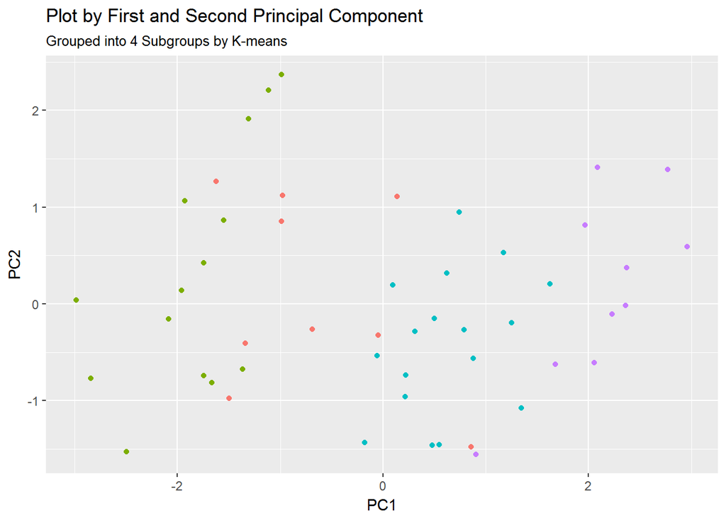

```r
# set the random seed
set.seed(1234)

# estimate k=4 clusters

# modify original dataframe to include kmeans cluster assignment and PC1 and PC2 scores
k4clust <- crime %>%
    mutate(k4 = as.factor(kmeans(crime[,2:5], 4, nstart = 1)$cluster),
           PC1 = as.data.frame(pr.out$x)$PC1,
           PC2 = as.data.frame(pr.out$x)$PC2)

#  plot each data point on the PC1 and PC2 component with each state color-coded by cluster membership
k4clust %>%
  ggplot(aes(PC1, PC2, color = k4)) +
  geom_point() +
  theme(legend.position = "none") +
  labs(title = "Plot by First and Second Principal Component",
       subtitle = "Grouped into 4 Subgroups by K-means")
```

4. Perform K-means clustering with K=3. Plot the observations on the first and second principal components and color-code each state based on their cluster membership. Describe your results.

The K-means clustering with K=3 is split along the “violent” and “less violent” spectrum, as expressed by PC1. The delineation between clusters at the edges are not especially distinct.

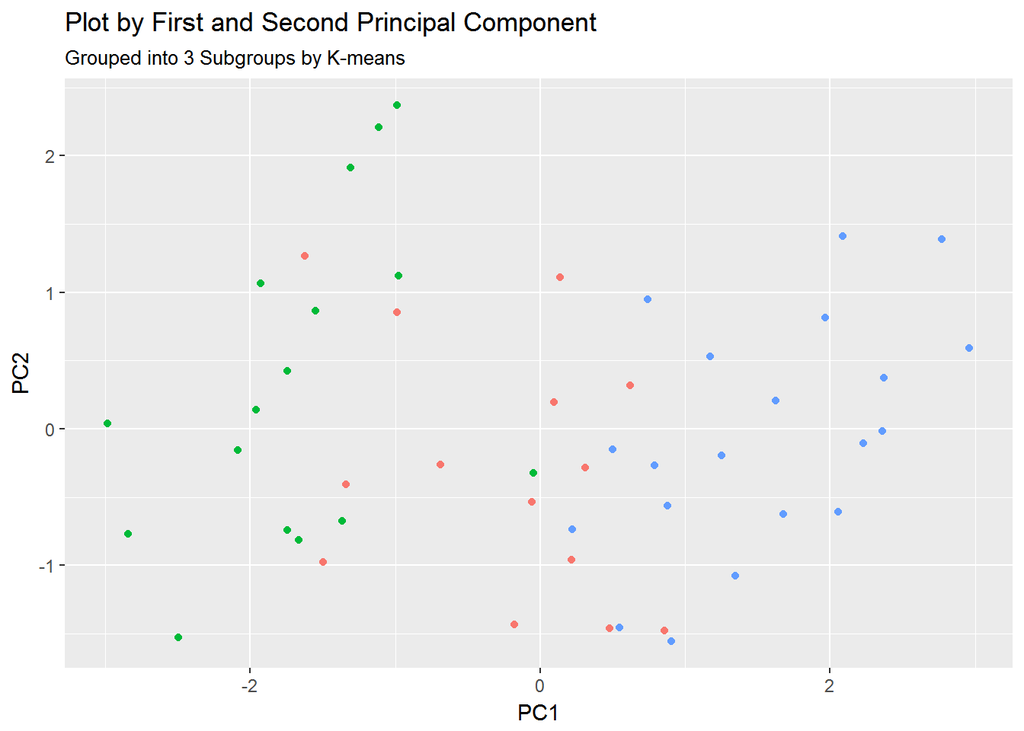

```r
# set the random seed
set.seed(1234)

# estimate k=3 clusters

# modify original dataframe to include kmeans cluster assignment and PC1 and PC2 scores
k3clust <- crime %>%
    mutate(k3 = as.factor(kmeans(crime[,2:5], 3, nstart = 1)$cluster),
           PC1 = as.data.frame(pr.out$x)$PC1,
           PC2 = as.data.frame(pr.out$x)$PC2)

#  plot each data point on the PC1 and PC2 component with each state color-coded by cluster membership
k3clust %>%
  ggplot(aes(PC1, PC2, color = k3)) +
  geom_point() +
  theme(legend.position = "none") +
  labs(title = "Plot by First and Second Principal Component",
       subtitle = "Grouped into 3 Subgroups by K-means")
```

5. Perform K-means clustering with K=3 on the first two principal components score vectors, rather than the raw data. Describe your results and compare them to the clustering results with K=3 based on the raw data

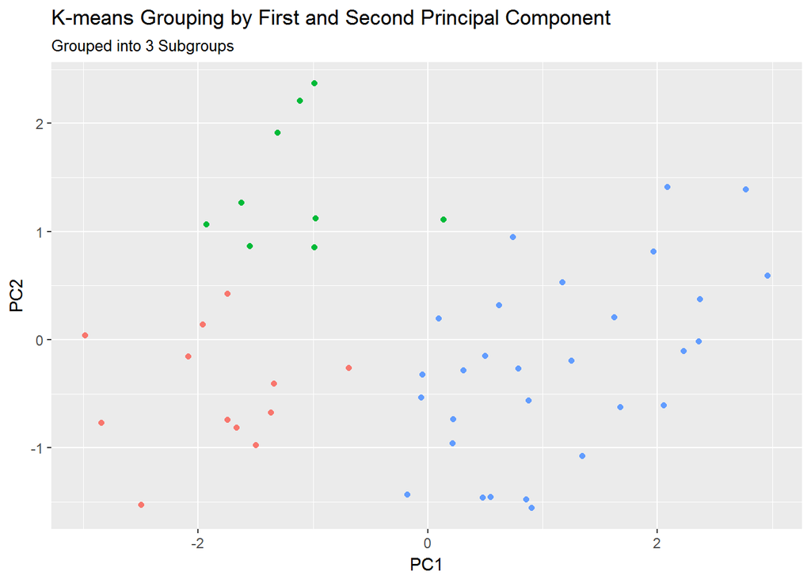

```r
# set the random seed
set.seed(1234)

# estimate k=3 clusters first two principal components score vectors, rather than the raw data: simply add the new kmeans cluster id to the k3clust dataframe from above
k3clust_mod <- k3clust %>%
    mutate(k3mod = as.factor(kmeans(k3clust[,7:8], 3, nstart = 1)$cluster))

#  plot each data point on the PC1 and PC2 component with each state color-coded by cluster membership
k3clust_mod %>%
  ggplot(aes(PC1, PC2, color = k3mod)) +
  geom_point() +
  theme(legend.position = "none") +
  labs(title = "K-means Grouping by First and Second Principal Component",
       subtitle = "Grouped into 3 Subgroups")
```

```r
k3clust_mod
```

```
## # A tibble: 50 × 9
##          State Murder Assault UrbanPop  Rape     k3         PC1
##          <chr>  <dbl>   <int>    <int> <dbl> <fctr>       <dbl>
## 1      Alabama   13.2     236       58  21.2      2 -0.97566045
## 2       Alaska   10.0     263       48  44.5      2 -1.93053788
## 3      Arizona    8.1     294       80  31.0      2 -1.74544285
## 4     Arkansas    8.8     190       50  19.5      1  0.13999894
## 5   California    9.0     276       91  40.6      2 -2.49861285
## 6     Colorado    7.9     204       78  38.7      1 -1.49934074
## 7  Connecticut    3.3     110       77  11.1      3  1.34499236
## 8     Delaware    5.9     238       72  15.8      2 -0.04722981
## 9      Florida   15.4     335       80  31.9      2 -2.98275967
## 10     Georgia   17.4     211       60  25.8      1 -1.62280742
## # ... with 40 more rows, and 2 more variables: PC2 <dbl>, k3mod <fctr>
```

6. Using hierarchical clustering with complete linkage and Euclidean distance, cluster the states.

Hierarchical clustering was used to cluster the states. The dendrogram is plotted below.

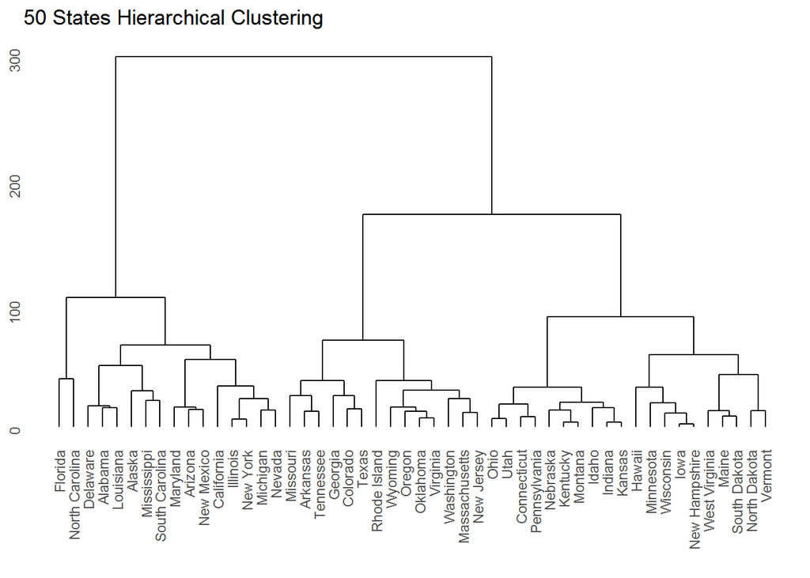

```r
# modify dataset so that State names will show up on the dendrogram, might as well also remove "State" now
hc_dat <- as.matrix(select(crime, -State))
rownames(hc_dat) <- crime$State

# run the hierarchical clustering using Euclidian distance
hc_complete <- hclust(dist(hc_dat), method = 'complete')

# plot the dendrogram
hc1 <- ggdendrogram(data = hc_complete, labels = TRUE) +
  geom_text() +
  labs(title = '50 States Hierarchical Clustering',
       y = 'Euclidean Distance')

hc1
```

7. Cut the dendrogram at a height that results in three distinct clusters. Which states belong to which clusters?

The table showing the state and cluster assignment is provided below. The table has been sorted by cluster.

```r
# cut the tree so that clusters = 3; turn results into a data frame
p7_cut <- cutree(hc_complete, k = 3) %>%
  data_frame(State = names(.), Cluster = .)

# sort the states by cluster assignment
p7_out <- arrange(p7_cut, Cluster)

# view states by cluster assignment
p7_out
```

```
## # A tibble: 50 × 2
##         State Cluster
##         <chr>   <int>
## 1     Alabama       1
## 2      Alaska       1
## 3     Arizona       1
## 4  California       1
## 5    Delaware       1
## 6     Florida       1
## 7    Illinois       1
## 8   Louisiana       1
## 9    Maryland       1
## 10   Michigan       1
## # ... with 40 more rows
```

8. Hierarchically cluster the states using complete linkage and Euclidean distance, after scaling the variables to have standard deviation 1. What effect does scaling the variables have on the hierarchical clustering obtained? In your opinion, should the variables be scaled before the inter-observation dissimilarities are computed? Provide a justification for your answer.

Scaling all the variables to have standard deviation of 1 effectively places equal weight on each variable in the hierarchical clustering performed. As the analysis above showed, the degree of reported violence seems to have a very important role in describing variation between states. If we scale all the variables as suggested, we will impact our ability to accurately account for the contribution of those variables that describe “violence.” Since these variables seem to be very descriptive of data variance, it is probably not a good idea to scale the variables accordingly.

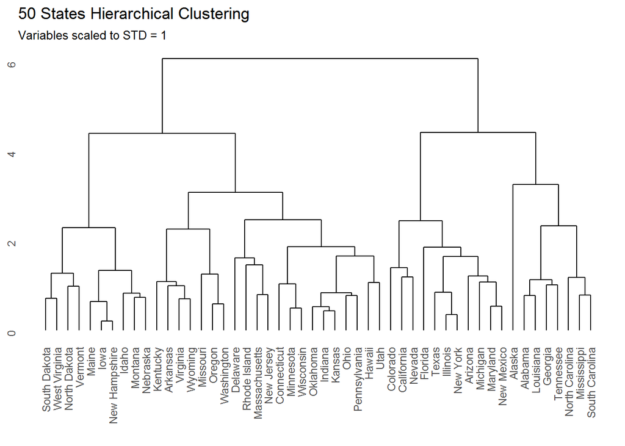

```r
# scale the data
hc_dat_scale <- scale(hc_dat)

# run the hierarchical clustering using Euclidian distance
hcscale_complete <- hclust(dist(hc_dat_scale), method = 'complete')

# plot the dendrogram
hc2 <- ggdendrogram(data = hcscale_complete, labels = TRUE) +
  geom_text() +
  labs(title = '50 States Hierarchical Clustering',
       subtitle = 'Variables scaled to STD = 1',
       y = 'Euclidean Distance')

hc2
```